# 언어심리학을 위한 데이터 사이언스 12주차: 데이터 사이언스 #5 (재현가능 연구)

12주차 퀴즈 파일

2022-05-26

# 1. **rmarkdown**과 **knitr**을 사용한 R 마크다운 문서 작성

## (1) 개관

- 마크다운(markdown)
  - 정의: 문서 생성 및 formatting을 위한 마크업(markup) 언어.
  - **rmarkdown** 패키지
    - 텍스트, R 코드, R 코드 결과물을 통합하여 다양한 형식([EX] HTML, MS 워드, PDF 등)의 문서로 만들어줌.
    - R 마크다운 문서(R markdown document, 이하 Rmd)
      - R 스크립트보다 훨씬 가독성이 높고, 다양한 정보를 포함할 수 있음.
      - YAML 메타데이터/제목, 텍스트, 코드 덩이(code chunk)로 구성됨.

**[그림 1] R을 통해 생성할 수 있는 다양한 문서 결과물의 형태**

[figure not shown]

- 출처: https://www.rstudio.com/wp-content/uploads/2015/03/rmarkdown-reference.pdf
- 주요 리소스
  - [**R Markdown: The Definitive Guide**](https://bookdown.org/yihui/rmarkdown/)
  - [**RStudio Lessons**](https://rmarkdown.rstudio.com/lesson-1.html)

## (2) 기본 문법

### A. 제목 텍스트

1. 해시태그 #를 하나씩 덧붙일 때마다 수준이 내려감.
2. 제목 1, ## 제목 2, ## 제목 3…

### B. 단순 텍스트

- 단순 텍스트: YAML 제목 밑에 텍스트를 써서 붙이면 됨. 새로운 단락을 시작하려면 줄바꿈을 하거나, 텍스트 라인 뒤에 스페이스를 2개 두면 됨.

### C. 볼드체와 이탤릭체

- **볼드**
- *이탤릭체*

### D. 리스트

- 순서를 매기지 않은 리스트
  - 리스트 1
    - 하위 리스트 1
    - 하위 리스트 2
  - 리스트 2
    - 하위 리스트 1
    - 하위 리스트 2
- 순서를 매긴 리스트
  1. 리스트 1
  2. 리스트 2

### F. 인용

#### 1) 블록 인용(blockquote)

> 텍스트 블록 인용.

#### 2) 단순 인용

```
텍스트 단순 인용.
```

- 코드 덩이 1

```r
1247 * 12
## [1] 14964
sqrt(533)
## [1] 23.08679
```

- 코드 덩이 2

```r
# 플롯의 너비는 7, 높이는 4, 위치는 왼쪽으로 설정해주세요.
library(tidyverse)
```

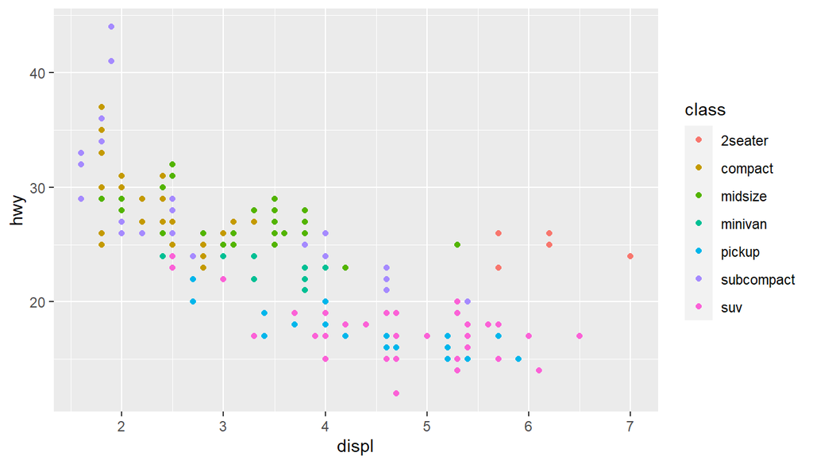

```r
ggplot(mpg, aes(x = displ, y = hwy, color = class)) +
  geom_point()
```

- 코드 덩이 3

```r
library(car)
library(broom)
load("pupluv_tib.1.rda")

# 유형 III 제곱합을 사용하여 모형 적합도 분석하기.
pupluv_tib.lm <- lm(happiness ~ puppy_love + dose, data = pupluv_tib.1, na.action = na.exclude) %>%
  Anova(type = 3)
tidy(pupluv_tib.lm)
```

```
## # A tibble: 4 x 5
##   term        sumsq    df statistic p.value
##   <chr>       <dbl> <dbl>     <dbl>   <dbl>
## 1 (Intercept)  12.9     1      4.26  0.0492
## 2 puppy_love   15.1     1      4.96  0.0348
## 3 dose         25.2     2      4.14  0.0274
## 4 Residuals    79.0    26     NA    NA
```

- 코드 덩이 4

```r
load("cloak_tib.rda")

cloak_tib_mod <- t.test(mischief ~ cloak, data = cloak_tib, na.action = na.exclude)
tidy(cloak_tib_mod)
```

[output not shown]

- 표 제시하기.

**<표 1> iris 데이터셋 표**

| Sepal.Length | Sepal.Width | Petal.Length | Petal.Width | Species |
| --- | --- | --- | --- | --- |
| 5.1 | 3.5 | 1.4 | 0.2 | setosa |
| 4.9 | 3.0 | 1.4 | 0.2 | setosa |
| 4.7 | 3.2 | 1.3 | 0.2 | setosa |
| 4.6 | 3.1 | 1.5 | 0.2 | setosa |
| 5.0 | 3.6 | 1.4 | 0.2 | setosa |
| 5.4 | 3.9 | 1.7 | 0.4 | setosa |
| 4.6 | 3.4 | 1.4 | 0.3 | setosa |
| 5.0 | 3.4 | 1.5 | 0.2 | setosa |
| 4.4 | 2.9 | 1.4 | 0.2 | setosa |
| 4.9 | 3.1 | 1.5 | 0.1 | setosa |
| 5.4 | 3.7 | 1.5 | 0.2 | setosa |
| 4.8 | 3.4 | 1.6 | 0.2 | setosa |
| 4.8 | 3.0 | 1.4 | 0.1 | setosa |
| 4.3 | 3.0 | 1.1 | 0.1 | setosa |
| 5.8 | 4.0 | 1.2 | 0.2 | setosa |
| 5.7 | 4.4 | 1.5 | 0.4 | setosa |
| 5.4 | 3.9 | 1.3 | 0.4 | setosa |
| 5.1 | 3.5 | 1.4 | 0.3 | setosa |
| 5.7 | 3.8 | 1.7 | 0.3 | setosa |
| 5.1 | 3.8 | 1.5 | 0.3 | setosa |
| 5.4 | 3.4 | 1.7 | 0.2 | setosa |
| 5.1 | 3.7 | 1.5 | 0.4 | setosa |
| 4.6 | 3.6 | 1.0 | 0.2 | setosa |
| 5.1 | 3.3 | 1.7 | 0.5 | setosa |
| 4.8 | 3.4 | 1.9 | 0.2 | setosa |
| 5.0 | 3.0 | 1.6 | 0.2 | setosa |
| 5.0 | 3.4 | 1.6 | 0.4 | setosa |
| 5.2 | 3.5 | 1.5 | 0.2 | setosa |
| 5.2 | 3.4 | 1.4 | 0.2 | setosa |
| 4.7 | 3.2 | 1.6 | 0.2 | setosa |

[output cut: 120 more lines]